# Political Influence on Offshore Economic Activity: An Analysis of the Panama Papers

Jacob Carter Duran

May 3rd, 2019

Abstract

Participation in the offshore economy involves the creation of an account or shell company in a foreign country for the express purpose of storing money there. While the process is usually legal, it is often linked to illegal activities such as tax evasion and money laundering. Previous literature describes the offshore economy as enormous, highly international and influenced on a country level basis by government structure. This paper asks how governance impacts the decision of whether to set up an offshore account locally, or whether to do so abroad. To do this, data from the Panama papers is regressed on worldwide governance indicators. The results show firms in countries with stronger governments attract an international clientele. Additionally, individual actors make different investment decisions based on different kinds of local government structure. This supports previous literature suggesting governance structures the behavior of participants in the offshore economy.

## Introduction

The offshore economy is one in which money is made to disappear. Persons with means use foreign economies and legislative loopholes to store money in locations they have no attachment to. While the process is usually legal, it is often linked to illegal activities such as tax evasion and money laundering. Because of its shadowy nature, the world of offshore finance is not a well understood one. Information on the subject is rare, and formal data sets describing it are even rarer.

The enormous 2016 data leak known as the Panama papers was an important event for the study of offshore finance. The anonymous leak consisted of the release of 2.6 terabytes of information regarding the offshore activities of individuals across the globe. This provides a functional set of evidence through which the actual behavior of participants in the offshore economy can be studied.

The main objective of this study is to understand how political structure impacts the decisions of individuals seeking to engage in the use of offshore accounts. Specifically, how governance impacts the decision of whether to set up an offshore account locally, or whether to do so abroad. Even though offshore finance is a world not easily seen, it is still a world influenced by political constraint.

## Literature

#### Tax Havens, Offshore Financial Centres and Underground Money

There is a wealth of literature that seeks to make sense of the nature and impact of the offshore economy.

An offshore financial centre, or tax haven, could be defined as any financial centre where offshore activity takes place. This definition is extremely broad, and would include financial centres like New York and London. More commonly, the term is applied to economies that offer a preferential tax rate and strong bank secrecy laws to hyper-mobile foreign economic actors who are able to easily switch location should the government cease to comply. In this way, economies are “rented out” for private benefit. (Mugarura 2017) The formal list of tax havens used in this analysis can be found in the appendix, and is drawn from Johannesen and Zucman (2014).

The literature related to tax havens and offshore finance indicates it is a large, international issue. It is a phenomenon largely driven by the actions of internationally-connected and wealthy firms and individuals. The true size of the offshore economy is fundamentally impossible to know, but research suggests it is very large, and its incorporation into statistical representations of the international economy creates a very different picture than what is commonly portrayed.

Gabriel Zucman’s work (2013) is seminal in its identification of the sheer magnitude of the offshore economy. The focus of the work concentrates on statistical discrepancies in the net foreign asset positions of wealthy countries, the US and the Eurozone in particular. Zucman estimates a staggering 8% of global financial wealth is held in tax havens, and accounting for this wealth changes the status of the Eurozone from a net debtor to a net creditor, and significantly reduces the size of American foreign debt.

Desai, Foley and Hines (2006) look at the influence firm characteristics have on the use of tax havens. Their analysis is focused on American firms, finding that larger, more international firms with high intra-firm trade and R&D intensities exhibit greater demand for tax haven operations.

#### Other Uses of The Panama Papers

Since their release, the Panama papers have unsurprisingly been used several times in order to study the offshore economy. Building on earlier research, Alstadsaeter, Johannesen and Zucman (2017) use the Panama papers in order to study its impact on, and relationship with wealth inequality in rich countries. Isolating their analysis to Scandinavia, they find on average about 3% of personal taxes are evaded, but this number jumps to close to 30% when looking at the top 0.01% of the income distribution. They estimate at least 50% of the wealth in tax havens to be owned by members of this income bracket.

The Panama papers have also been used in various ways to study the impact government has on offshore economic activity. For example, Bayer et Al. (2018) look at the influence of property confiscations on offshore account activity. They find that offshore account incorporation increases with the reporting of property confiscation spells, particularly in developed countries as governments make concerted efforts to hide proceeds from crime. Andersen et Al. (2017) find increases in petroleum income are associated with increases in hidden wealth, but only in autocratic nations.

Others use the data as a way to understand how leaks like these impact the offshore economy more broadly. Donovan et Al. (2018) note observe drops in asset value for firms connected to the Panama papers, associated with the occurrence of the leak. They suggest that after the leak implicated firms avoid less tax. This indicates that leaks like the Panama papers have an impact on the ability of companies to continue to use offshore accounts to hide money.

#### Efforts to Stop the Problem

As the offshore economy is a large and international issue, coordinated international efforts have been implemented to try and stop it. Caruana-Galizia & Caruana-Galizia (2016) assess the impact of the anti tax evasion 2005 EU Tax and savings directive on offshore account activity, using Panama papers data. They find that the the directive was associated with a decline in offshore accounts explicit held by Europeans, but also an increase in non-EU-owned offshore entities, which they argue is due to a substitution effect.

Johannesen and Zucman (2014) come to a similar conclusion in their analysis of G20 efforts to increase transparency with tax havens through bilateral bank information disclosure treaties. Rather than repatriating funds, they find that the creation of these treaties instead relocates deposits to less compliant tax havens.

Mugarura (2017) argues that part of the reason efforts to curb offshore have not been successful is in part due to inconsistent application. He notes the disproportionate penalties that less developed tax havens like the Seychelles face compared to more established economies that are still greatly involved in offshore finance, like Switzerland. He argues in order to effectively combat offshore finance, there is a need for more even application of anti-tax evasion efforts.

In short, the literature describes the offshore economy as enormous and highly international in nature. It is influenced on a country level basis by government structure in a number of ways. Much of the money in offshore accounts is held by the very wealthy, and efforts to draw this money back into the countries it originates from have been largely unsuccessful, in part due to inconsistent application of efforts. Leaks like the Panama papers have proved indispensable in helping shed some light on a highly complex and relatively unknown world.

## Motivation

While the question of how political structure affects the behavior of individuals looking to set up offshore accounts has been asked many times before, this paper has a number of differences with the existing literature. Primarily, while there is great existing interest in contributing factors to an individual’s decision to make an offshore account, the firms who enable this decision have received relatively little attention. In the Panama papers, the individuals who make these decisions are listed as “officers”, and the firms who facilitate this are listed as “intermediaries”. The accounts and companies created are listed as “entities”. So, the creation of an offshore entity can be thought of as a decision made by an officer, enabled by an intermediary. While there are undoubtedly many ways for individuals to hide their money, the use of a legitimate and discreet financial service or legal firm seems an obvious choice for a person with the means to do so. However, which intermediary to choose is a decision made by the officer in question.

There are 202 countries represented in the Panama papers, and a total of 309,357 officer-entity connections. This is a massive, and truly international phenomenon. Considering the inherently covert nature of the offshore economy, officers have considerable leeway when choosing a suitable intermediary to set up their offshore account. Government structure has a plausible effect on this decision. The structure of the government where the officer and intermediary reside has obvious implications for the decision-making process related to the creation of an offshore account. These actions are usually not illegal per se, but are inextricably linked with a wide variety of illegal processes ranging from tax evasion to money laundering.

Does government structure impact the decisions of officers looking to set up an offshore entity? Does it impact the clientele of the intermediaries who enable the creation of these entities? This analysis seeks to answer both of these questions, by examining whether officers choose to use a local or foreign intermediary based on government structure, and whether this same structure influences the domestic or foreign nature of intermediary clientele.

## Data

The data used in this project is from two sources, the World Bank and the offshore documents leak known as the Panama papers.

### Panama Papers

The Panama papers is a set of offshore financial network data released via an anonymous leak at the Panamanian law firm Mossack Fonseca. The leak occurred on March 9th, 2016, although news of the leak was not made public until April 3rd. Among the largest data leaks in history, the Panama papers leak involved the release of 11.5 million documents, for a total of 2.6 terabytes of data. Mossack Fonseca was founded by two lawyers, Jürgen Mossack and Ramón Fonseca, in 1986 (Fitzgibbon, 2018 a.). It is purported to have once been the fourth-largest offshore service provider in the world (Harding 2016), although since the leak the firm’s offices have closed (Fitzgibbon, 2018 b.). The data was leaked via anonymous submission to the German newspaper Süddeutsche Zeitung, and to the International Consortium of Investigative Journalists (ICIJ). The ICIJ processed the documents into network format, and released it publicly in both the form of an online database and for direct download.

The network is divided into 4 different node types; entities, intermediaries, officers and addresses. An offshore **entity** is defined as “a company, trust or fund created by an agent in a low-tax jurisdiction that often attracts non-resident clients through preferential tax treatment.” (ICIJ 2019) Mossack Fonseca is the service provider for the incorporation of the offshore entities in the Panama Papers. However, it incorporated these companies at the request of intermediaries, who made these requests for individual officers. **Officers** and **intermediaries** are defined as, respectively; “a person or company who plays a role in an offshore entity” and “a go-between for someone seeking an offshore corporation and an offshore service provider – usually a law-firm or a middleman that asks an offshore service provider to create an offshore firm for a client.” (ICIJ) The fourth node type, addresses represent “Contact postal address as it appears in the original databases obtained by ICIJ.” (ICIJ) The question of interest in this study is associated with intermediary-officer behaviour. To facilitate this, the data set had to be reconstructed to create an intermediary-officer network.

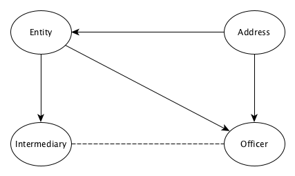

The above diagram illustrates the structure of connections as originally obtained from the Panama papers. The solid arrows indicate the direction of connections, although direction has no substantive importance in this network. The dotted line represents the desired relationship, which was obtained through the bipartite transformation.

Summary of Connections in the Panama Papers

|  | Entity (Incoming) | Officer (Incoming) | Address (Incoming) | Intermediary (Incoming) |
| --- | --- | --- | --- | --- |
| Entity (Outgoing) | 0 | 309357 | 0 | 213634 |
| Officer (Outgoing) | 0 | 5 | 0 | 0 |
| Address (Outgoing) | 5310 | 145795 | 0 | 0 |
| Intermediary (Outgoing) | 0 | 1 | 0 | 0 |

The above table details how the various kinds of nodes are connected, as originally obtained from the ICIJ. The important thing to note is how entities connect to both intermediaries and officers, forming a link between the two. Save for six edges, which were dropped for the analysis, intermediaries and officers connect neither to themselves, nor to each other.

### World Bank data

The World Bank was used as a source for two main kinds of data, general demographic indicators, and the Worldwide Governance Indicators (WGI’s). GDP and population were retrieved, and used to construct the GDP per capita variable. For use in regressions, both GDP and GDP per capita were log transformed.

#### WGI’s

The WGI’s are a set of aggregate indicators created by Kaufmann and Kraay (2017), and distributed by the World Bank. They are broad descriptive summaries of various dimensions of governance between countries. The indicators are: Regulatory Quality, Rule of Law, Control Of Corruption, Government Effectiveness, Political Stability and Voice and Accountability. They are aggregates of other summary indicators as well as summaries of various demographic surveys. Regulatory Quality refers to the strength of private sector regulation, Rule of Law to the strength of the judicial system and Control of Corruption to the perceived trustworthiness of public servants. Political Stability refers to the level of violence or potential violence in a country and Voice and Accountability refers to citizen freedom and government accountability to its citizens. It is used as a proxy for level of democracy or authoritarianism. Government Effectiveness is the broadest of all measures, referring to overall perceived quality of governance. More detailed descriptions of each one can be found in the appendix.

## Methods

### Time

To incorporate the element of time, the data was divided into 4 windows; 1996-2000, 2001-2005, 2006-2010 and 2011-2015. All World Bank indicators are the mean of the yearly indicators across each time period.

For the Panama Papers data, each indicator was calculated separately based on the accounts existing in each time period. So, for example, an offshore entity incorporated in 1999 and deactivated in 2012 would be reflected in the statistics of all 4 windows, and an offshore entity incorporated in 2007 and deactivated in 2012 would only be reflected in the statistics of the last 2 windows. In the panama papers data, there are 2 different kinds of end dates, “inactivation” and “struck off” dates. Inactivation refers to the day an entity was formally deactivated, and struck off to the day the account holder stopped making payments and therefore lost their account. In this analysis, the earlier of the two was used.

### Construction of Panama Papers variables

To understand how government structure influences the actions of intermediaries and officers within the Panama Papers, the network had to be reconstructed to relate officers to the intermediaries they used to set up their offshore entities. Prior to the reconstruction, address nodes were dropped as they are not of conceptual importance to the intermediary-officer relationship. In addition, the highly central officer node “Mossack Fonseca Subscribers” was dropped in an effort to reduce bias, because its central position was likely due to the source of the data (Mossack Fonseca), rather than to its true centrality within the global offshore financial network.

This reconstruction was operationalized through a bipartite projection. Since officers do not connect to intermediaries, their linkage in the network is necessarily though the entity that connects them both. For the bipartite projection, nodes were coded either “entity” or “not entity”. This way, an additional edge is created between any two nodes connected to the same entity. This also has the unintended effect of connecting any two officers linked to the same entity, however this issue was solved by dropping all officer-officer and intermediary-intermediary edges after the projection.

Once in bipartite format, the network represents the relationships between officers and the intermediaries connected via the incorporation of an offshore entity. Network variables were obtained through calculations on this graph. Specifically, there were 3 network variables of interest for each node: degree, proportion of local connections and proportion of connections not available. Degree refers to the number of connections that each node has with other nodes in the network. The proportion variables refer to the share of these connections based on two characteristics; whether the connected node is in the same country and whether the connected node’s country information is available. The two proportions can be thought of as “domestic proportion” and “proportion unavailable”.

The substantive importance of domestic proportion means something different for intermediaries and officers. In this model, the officers are the decision makers, they choose whether to do business locally or in a foreign country. For intermediaries, domestic proportion reflects their clientele, the geographic locations of the individuals who choose to do business with them. An intermediary that enables actors in their own country to create offshore entities is different than one that primarily services foreign actors.

Proportion unavailable has a slightly more complex meaning. A number of officers in the Panama papers are listed as “The Bearer” or “El Portador”, indicating that the entity is at least partially owned by bearer shares. Bearer shares are shares of an entity considered owned by the physical owner of a share certificate, a deep level of secrecy. In the data set, bearer officers often have no corresponding country information, and are represented in the proportion unavailable variable. Proportion unavailable is therefore determined by the lack of available country data, but it is important to note that this is not necessarily by accident. Once variables were calculated at the individual node level, they were then aggregated at the country level using a weighted average. Unavailable proportions were weighted by degree, and domestic proportions by available degree, that is: Weight = (Degree(1 - Prop. Unavailable)).

Due to the vagueness in its substantive meaning, unavailable proportion was not used as an outcome variable for this analysis, however its construction is integral in accounting for missing information when aggregating domestic proportion.

The below table provides a summary of all network-related variables, once aggregated at the country level.

Officer Characteristics

| Variable | n | mean | median | sd | max | min | range | IQR |
| --- | --- | --- | --- | --- | --- | --- | --- | --- |
| Proportion Domestic | 417 | 0.23505 | 0.10000 | 0.27451 | 1.00000 | 0 | 1.00000 | 0.34640 |
| Proportion Unavailable | 417 | 0.03818 | 0.01566 | 0.06450 | 0.80000 | 0 | 0.80000 | 0.05106 |
| Average Degree | 417 | 1.01304 | 1.00000 | 0.03259 | 1.23591 | 1 | 0.23591 | 0.00980 |
| Number of Officers | 417 | 621.44844 | 133.00000 | 1685.50706 | 20721.00000 | 1 | 20720.00000 | 440.00000 |

Intermediary Characteristics

| Variable | n | mean | median | sd | max | min | range | IQR |
| --- | --- | --- | --- | --- | --- | --- | --- | --- |
| Proportion Domestic | 417 | 0.38693 | 0.35714 | 0.28289 | 1.0000 | 0 | 1.0000 | 0.40399 |
| Proportion Unavailable | 417 | 0.38947 | 0.35714 | 0.29532 | 1.0000 | 0 | 1.0000 | 0.49235 |
| Average Degree | 417 | 22.03896 | 7.72727 | 48.28120 | 449.6667 | 1 | 448.6667 | 14.55000 |
| Number of Intermediaries | 417 | 45.65947 | 7.00000 | 127.74793 | 1083.0000 | 1 | 1082.0000 | 27.00000 |

## Results

All results in this analysis were obtained through Ordinary Least Squares regression, using R version 3.5.2. Two kinds of OLS models were used in the analysis of this data, to determine the impact of government structure on two outcome variables; the domestic proportions of intermediaries and officers. For the officer-level domestic proportions, tax haven status, economy size (GDP), wealth (GDP per Capita), democracy level (Voice and Accountability) and time were controlled for. Additionally, only country-eras with ten or more officers were included in the regression. For the intermediary level proportions, all the same controls were used, with the exception of Voice and Accountability, the proxy variable for democracy level. For the intermediary regressions, only country eras with more than two intermediaries were used, unless the average degree of those intermediaries was over 9, as in they were connected to 10 officers.

The decision to include the Voice and Accountability variable for the officer-proportion regressions is justified by the fact that among the WGI’s, only Regulatory Quality and Rule of Law had any observed impact on the domestic proportions of officers. Thus, controlling for the presence of authoritarianism added to the robustness of the model without triggering an issue of competing effects. There is a conceptual likelihood that the presence of authoritarianism could influence the way officers make offshore investment decisions, so controlling for Voice and Accountability limits the potential for any kind of confounding effect (it is worth noting the effects are still significant in absence of the VA variable). In contrast, every WGI had an observed association with domestic proportion for intermediaries. The decision to exclude Voice and Accountability as a control here was in the interest of maintaining consistency between the regressions, and to avoid a competing effects problem in interpreting the results.

The WGI’s cannot be placed in the same regression due to collinearity issues, save for the Voice and Accountability measure. While the other measures are related to the effective functioning of government, and are thus very similar, Voice and Accountability is essentially a measure for democracy level. A well-functioning government administration undoubtedly supports democracy, and there is a positive relationship between Voice and Accountability and all other measures. However, highly effective governments also exist in authoritarian regimes as well, as evidenced by countries like China, Singapore and Russia. The heterogeneity in association observed between level of authoritarianism and government functioning therefore permits the use of Voice and Accountability as a control in regressions where the use of other WGI’s would be inappropriate.

### Political Influence on Officer Behaviour

|  | Regression Results: Dependent Variable Officer Domestic Proportion |  |
| --- | --- | --- |
|  | (1) | (2) |
| Regulatory Quality | 0.074** |  |
|  | (0.034) |  |
| Rule of Law |  | -0.111*** |
|  |  | (0.031) |
| Voice and Accountability | -0.037 | 0.046* |
|  | (0.024) | (0.024) |
| Tax Haven Dummy | 0.133*** | 0.147*** |
|  | (0.039) | (0.039) |
| GDP (Log) | 0.002 | 0.004 |
|  | (0.008) | (0.008) |
| GDP per Capita (Log) | -0.038** | 0.035* |
|  | (0.018) | (0.018) |
| Year | 0.0002 | -0.004 |
|  | (0.003) | (0.003) |
| Constant | 0.127 | 8.215 |
|  | (5.334) | (5.287) |
| Observations | 376 | 380 |
| R<sup>2</sup> | 0.056 | 0.081 |
| Adjusted R<sup>2</sup> | 0.040 | 0.067 |
| Residual Std. Error | 0.264 (df = 369) | 0.264 (df = 373) |
| F Statistic | 3.621*** (df = 6; 369) | 5.509*** (df = 6; 373) |
| *Note:* | p < 0.1 — * |  |
|  | p < 0.05 — ** |  |
|  | p < 0.01 — *** |  |

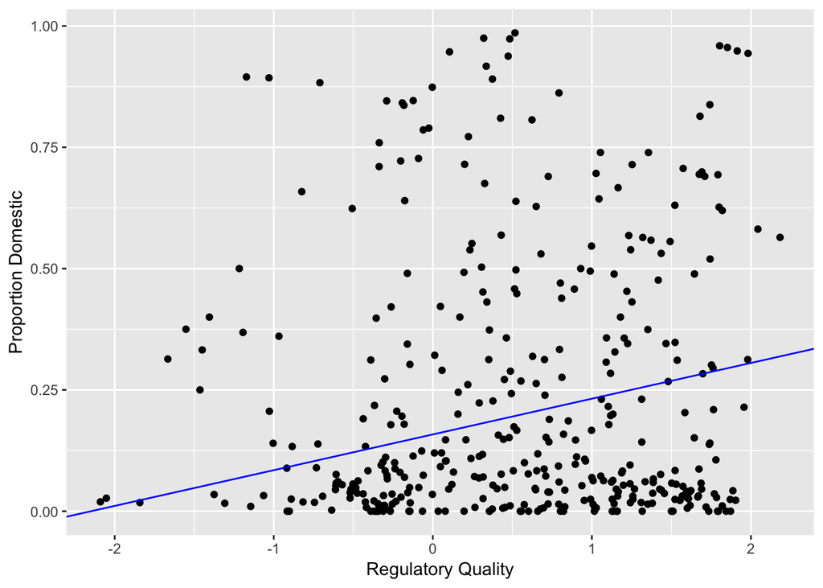

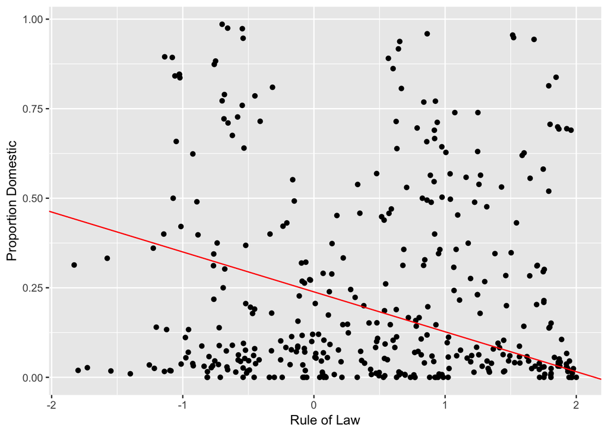

A country being classified as a tax haven by Johannesen and Zucman (2014) was associated with an approximately 14 percentage-point expected increase in domestic proportion for officers of that country. This is a logical finding, considering that if an officer is already in a tax haven they have less incentive to use foreign intermediaries to set up an offshore account.

The dichotomy observed in the direction of effects between Regulatory Quality and Rule of Law is a striking finding. These two variables are highly correlated, with a Pearson coefficient of 0.93. Yet, when used the same way as an explanatory variable for domestic proportion, they produce opposite results. The strength of the judicial system pushes participants in the offshore economy to look outside of the country to set up their offshore account. The strength of private sector regulation encourages them to stay local. Highly related but ultimately distinct dimensions of government have opposite effects on the behavior of participants in the offshore economy. This supports notions of offshore economic activity as structured by government, but emphasizes that the way government structure is defined is of crucial importance.

### Political Influence on Intermediary Behavior

|  | Regression Results: Dependent Variable Intermediary Domestic Proportion |  |  |  |  |  |
| --- | --- | --- | --- | --- | --- | --- |
|  | (1) | (2) | (3) | (4) | (5) | (6) |
| Rule of Law | -0.170*** |  |  |  |  |  |
|  | (0.021) |  |  |  |  |  |
| Government Effectiveness |  | -0.184*** |  |  |  |  |
|  |  | (0.025) |  |  |  |  |
| Regulatory Quality |  |  | -0.119*** |  |  |  |
|  |  |  | (0.024) |  |  |  |
| Control of Corruption |  |  |  | -0.133*** |  |  |
|  |  |  |  | (0.022) |  |  |
| Political Stability |  |  |  |  | -0.126*** |  |
|  |  |  |  |  | (0.021) |  |
| Voice and Accountability |  |  |  |  |  | -0.085*** |
|  |  |  |  |  |  | (0.017) |
| Tax Haven Dummy | 0.066** | 0.088** | 0.064* | 0.068* | 0.052 | 0.048 |
|  | (0.033) | (0.034) | (0.035) | (0.035) | (0.034) | (0.035) |
| GDP (Log) | 0.035*** | 0.043*** | 0.037*** | 0.035*** | 0.018** | 0.027*** |
|  | (0.007) | (0.007) | (0.008) | (0.007) | (0.007) | (0.007) |
| GDP per Capita (Log) | 0.039** | 0.035** | -0.005 | 0.020 | -0.001 | -0.024* |
|  | (0.016) | (0.017) | (0.016) | (0.018) | (0.015) | (0.013) |
| Year | 0.001 | 0.001 | 0.004 | 0.002 | 0.004* | 0.006** |
|  | (0.002) | (0.002) | (0.002) | (0.002) | (0.002) | (0.002) |
| Constant | -2.815 | -3.022 | -7.545 | -5.237 | -8.097* | -11.203** |
|  | (4.608) | (4.776) | (4.917) | (4.877) | (4.719) | (4.670) |
| Observations | 316 | 312 | 312 | 312 | 314 | 316 |
| R<sup>2</sup> | 0.286 | 0.274 | 0.213 | 0.239 | 0.231 | 0.199 |
| Adjusted R<sup>2</sup> | 0.275 | 0.262 | 0.200 | 0.226 | 0.219 | 0.186 |
| Residual Std. Error | 0.205 (df = 310) | 0.208 (df = 306) | 0.217 (df = 306) | 0.213 (df = 306) | 0.213 (df = 308) | 0.217 (df = 310) |
| F Statistic | 24.866*** (df = 5; 310) | 23.112*** (df = 5; 306) | 16.519*** (df = 5; 306) | 19.187*** (df = 5; 306) | 18.518*** (df = 5; 308) | 15.414*** (df = 5; 310) |
| *Note:* | p < 0.1 — * |  |  |  |  |  |
|  | p < 0.05 — ** |  |  |  |  |  |
|  | p < 0.01 — *** |  |  |  |  |  |

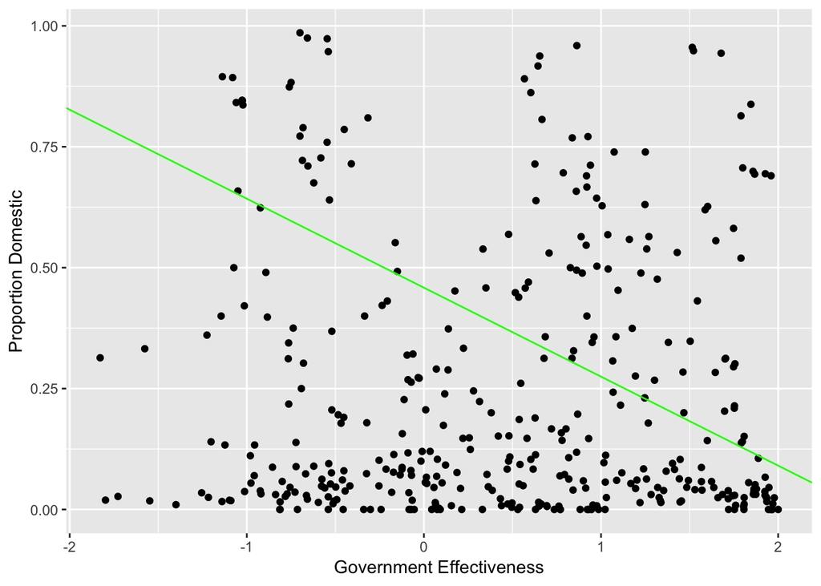

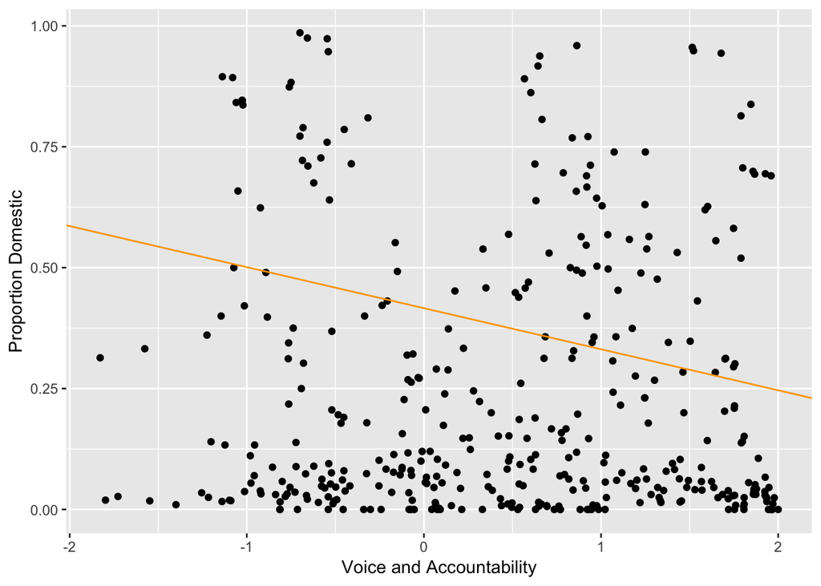

As described previously, the interpretation for domestic proportion for intermediaries is different than it is for officers. Officers are decision makers. They choose whether or not to use local intermediaries. This is not to discount the ability of intermediaries to choose their clientele, but fundamentally the officers are the actors in this network.

Across all six WGI’s there is a unified and strikingly significant negative association between development of political structure and domestic proportion for intermediaries. This indicates that country-eras with more developed governments as measured by all six aggregate indicators have lower predicted domestic proportions. This suggests that in intermediaries in countries with strong governments attract outside use of their intermediaries.

As similarly discussed in the results section for officers, the tax haven dummy variable has a positive coefficient in the intermediary regression as well. However, the effect size is considerably lower for domestic proportion of intermediaries than for officers. This indicates that officers in tax havens are more likely to use local intermediaries than intermediaries are to attract local officers. This suggests there is a higher incentive to stay local if one is an officer in a tax haven, but for intermediaries the same sized incentive is not present.

## Discussion

This analysis supports previous claims that offshore investment related decisions are in many ways shaped by political structure.

It appears intermediaries in countries with well-developed governments are more likely to have lower domestic proportions as in more foreign investors. This suggests a possible preference for intermediaries embedded in a high quality and effective government structure when officers are looking for a party through which to set up an offshore account. This could be explained by the presence of superior intermediaries in countries with strong governments, expectations of investment stability associated with strong government, or many other reasons. Untangling the causes behind this preference are ultimately questions for other research, but what is clear is that the preference exists.

Different dimensions of governance affect officer decisions to stay local when choosing an intermediary differently. Based on the results in this analysis, it appears officers are more likely to use a local intermediary when the regulatory quality, in the sense of private sector support, is higher in their home country. They are less likely to be associated with a local intermediary when the rule of law, as in confidence in the honesty and effectiveness of the legal system, is higher. This could be interpreted as aversion to situations of where possibility of punishment is higher, and affinity for regulatory frameworks conducive to private sector investment. Again, the specific mechanisms in play here are ultimately unclear, but what is apparent is that government structure has an impact on the decisions of officers in the offshore economy.

This paper can thus contribute to a body of literature that explains the decisions of actors in the offshore economy as decisions made with respect to political constraints. In the context of the broad debate on how to effectively address the problem of offshore finance, the impact rule of law has on officer decision making should emphasize the potential ability governments have in constraining the actions of would-be offshore investors. The impact of regulatory quality on officer behavior should emphasize the ways that well intended institutional frameworks have the potential for misuse by individuals with means. Finally, the tendency of intermediaries in countries with strong governments to attract foreign officers emphasizes the importance the importance of consistently applied anti-tax evasion measures. If attention is limited to less developed offshore financial centres, it does not deal with the issue at hand, only changes its form.

## Limitations

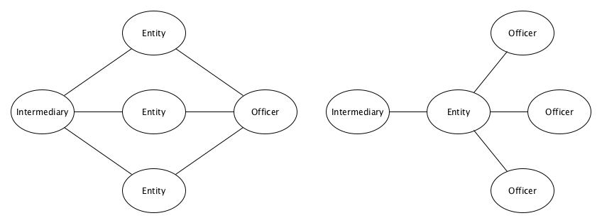

In the creation of the bipartite network, there were a couple necessary simplifications that could plausibly impact results. The first has to do with a complexities in intermediary-entity-officer connections that could not be incorporated into the intermediary-officer network. The diagram above illustrates this. The network on the left displays a relationship in which an officer is connected to an intermediary through three separate entities. In the bipartite transformation, patterns like this become a single intermediary-officer connection, rather than three separate ones. The network on the right displays a relationship in which an intermediary is connected to three officers through a single entity. In the bipartite transformation, this becomes three intermediary-officer connections. These simplifications are applied consistently in the transformation and therefore are unlikely to bias results, but ultimately do fail to address this relational nuance.

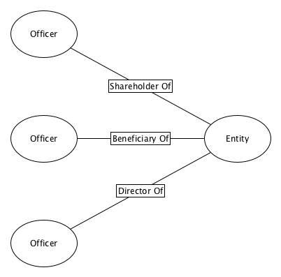

In the original Panama papers, there are multiple different kinds of connections entities can have with officers. “Shareholder of”, “beneficiary of” and “director of” are among the most common. In this analysis they are all treated as the same. This means that connections more accurately describe officer’s affiliation to a particular intermediary. This raises the issue that post bipartite transformation, connected intermediaries and officers may have never had an actual interaction. It is possible that one officer has made the transaction on behalf of all the other connected officers. While the methods used in this analysis gloss over this transaction nuance, they are still able to capture affiliation to an intermediary, an important relationship in and of itself.

An issue related to the use of the WGI’s as measures of governance is their broadness. The WGI’s are aggregate indicators, summaries of wide swaths of various other indicators. Because of this, they lack specificity. This paper is unable to provide any clear policy recommendations for this reason. Ultimately, the way that government impacts the nature of offshore finance is highly complex, and no one study will provide the answer for the regulation of this economy. So, in absence of specific policy recommendations, what this paper offers are policy directions; reifications of prior conclusions and avenues for further analysis.

## Conclusion

The world of offshore finance is complex, poorly documented and it is often hard to come to firm conclusions about its inner workings. Releases of data like the Panama papers mark an important opportunity for the study of offshore finance. Through this data, one can begin to get a picture of the economic, social and political processes that structure the offshore economy. This paper is an attempt to begin to disentangle the many ways political structure affects the actions of participants in the offshore economy.

Intermediaries in countries with stronger governments have consistently lower domestic proportions. This indicates that much of their clientele is international, and reifies the importance of consistently applied anti-tax haven efforts. Drawing on other literature, allowing more developed tax havens a free pass has limited the effectiveness of efforts to curb the scope of the offshore economy. Government structure was also seen to have an impact on the behavior of officers. Officers in countries with stronger regulatory quality in the private sector tend to use local intermediaries. Those in countries with a stronger rule of law tend to use foreign intermediaries. This suggests officers are able to take advantage of a well regulated local private sector in setting up their offshore accounts, and demonstrate an aversion to stronger legal systems by taking their business elsewhere. With these results in consideration, it appears that diminishing the size of the offshore economy starts domestically.

The offshore economy should not be taken lightly. It is a problem of enormous magnitude, and one that exists in the background of every discussion involving taxation or inequality. Government has been shown to have a defining effect on the way the offshore economy functions. The objective now needs to be using policy in a way that limits it rather than promotes its function. In an age where inequality is rampant, growing and present in every society, there could not be more urgency.

## References

Alstadsæter, Annette, Niels Johannesen, and Gabriel Zucman. 2017. “Tax Evasion and Inequality.” Working Paper Series 23772.

Andersen, Jørgen Juel, Niels Johannesen, David Dreyer Lassen, and Elena Paltseva. 2017. “Petro Rents, Political Institutions, and Hidden Wealth: Evidence from Offshore Bank Accounts.” Journal of the European Economic Association 15(4):818–60.

Bayer, Ralph-Christopher & Hodler, Roland & Raschky, Paul & Strittmatter, Anthony. 2018. “Expropriations, Property Confiscations and New Offshore Entities: Evidence from the Panama Papers.” CESifo Working Paper.

Caurana-Galizia, Paul and Caurana-Galizia, Matthew. 2016. “Offshore Financial Activity and Tax Policy: Evidence from a Leaked Data Set.” Journal of Public Policy 36(3):457-488.

Desai, Mihir A., C. Fritz Foley, and James R. Hines. 2006. “The Demand for Tax Haven Operations.” Journal of Public Economics 90(3):513–31.

Fitzgibbon, Will. 2018. “New Panama Papers Leak Reveals Firm’s Chaotic Scramble to Identify Clients, Save Business Amid Global Fallout,” International Consortium of Investigative Journalists, June 20. Accessed Online.

Fitzgibbon, Will. 2018. “Panama Papers Law Firm Mossack Fonseca Closes its Doors,” International Consortium of Investigative Journalists, March 14. Accessed Online.

Harding, Luke. 2016. “Mossack Fonseca: Inside the Firm that Helps the Super-Rich Hide Their Money,” The Guardian, April 8. Accessed Online.

International Consortium of Investigative Journalists. 2019. “Frequently Asked Questions.” Retrieved May 3rd, 2019 (https://offshoreleaks.icij.org/pages/faq).

Johannesen, Niels and Gabriel Zucman. 2014. “The End of Bank Secrecy? An Evaluation of the G20 Tax Haven Crackdown.” American Economic Journal: Economic Policy 6(1):65–91.

Mugarura, Norman. 2017. “Tax Havens, Offshore Financial Centres and the Current Sanctions Regimes.” Journal of Financial Crime 24(2):200–222.

O’Donovan, James, Hannes F. Wagner, and Stefan Zeume. 2019. “The Value of Offshore Secrets: Evidence from the Panama Papers.” The Review of Financial Studies (20190211).

Zucman, Gabriel. 2013. “The Missing Wealth of Nations Are Europe and the U.s. Net Debtors or Net Creditors?” The Quarterly Journal of Economics 128(3):1321–64.

### Data

International Consortium of Investigative Journalists. 2016. Panama Papers (Data). Retrieved September 26th, 2018 (https://offshoreleaks.icij.org/pages/database)

Kaufmann, Daniel & Kraay, Aart. 2017. Worldwide Governance Indicators. Retrieved January 13, 2019 (https://info.worldbank.org/governance/wgi/#home)

World Bank DataBank. 2018. Popular Indicators. Retrieved January 13, 2019 (https://databank.worldbank.org/data/home)

### Code

Csardi G, Nepusz T: The igraph software package for complex network research, InterJournal, Complex Systems 1695. 2006. http://igraph.org

Hadley Wickham (2017). tidyverse: Easily Install and Load the ‘Tidyverse’. R package version 1.2.1. https://CRAN.R-project.org/package=tidyverse

Hlavac, Marek (2018). stargazer: Well-Formatted Regression and Summary Statistics Tables. R package version 5.2.2. https://CRAN.R-project.org/package=stargazer

### Appendix A: Data Description

#### World Governance Indicators

Variable Description: Verbatim from World Bank

| Variable | Description |
| --- | --- |
| Regulatory Quality | Regulatory quality captures perceptions of the ability of the government to formulate and implement sound policies and regulations that permit and promote private sector development. |
| Rule of Law | Rule of law captures perceptions of the extent to which agents have confidence in and abide by the rules of society, and in particular the quality of contract enforcement, property rights, the police,… |
| Control of Corruption | Control of corruption captures perceptions of the extent to which public power is exercised for private gain, including both petty and grand forms of corruption, as well as ‘capture’ of the state by e… |
| Voice and Accountability | Voice and accountability captures perceptions of the extent to which a country’s citizens are able to participate in selecting their government, as well as freedom of expression, freedom of associatio… |
| Government Effectiveness | Government effectiveness captures perceptions of the quality of public services, the quality of the civil service and the degree of its independence from political pressures, the quality of policy for… |
| Pol. Stability/No Violence | Political Stability and Absence of Violence/Terrorism measures perceptions of the likelihood of political instability and/or politically- motivated violence, including terrorism. |

Summary Statistics of Country-Era Variables

| Variable | n | mean | median | sd | max | min | range | IQR |
| --- | --- | --- | --- | --- | --- | --- | --- | --- |
| Regulatory Quality | 409 | 0.5077331 | 0.5225 | 0.8664297 | 2.183333 | -2.0900 | 4.273333 | 1.395333 |
| Rule of Law | 413 | 0.4306223 | 0.5350 | 0.9526708 | 2.000000 | -1.8280 | 3.828000 | 1.670000 |
| Control of Corruption | 409 | 0.4395139 | 0.3450 | 1.0144588 | 2.424000 | -1.3720 | 3.796000 | 1.680000 |
| Voice and Accountability | 413 | 0.3690420 | 0.5280 | 0.9034262 | 1.694000 | -1.8760 | 3.570000 | 1.406000 |
| Government Effectiveness | 409 | 0.5204698 | 0.4800 | 0.9067969 | 2.308000 | -1.4160 | 3.724000 | 1.448000 |
| Pol. Stability/No Violence | 411 | 0.2671212 | 0.4300 | 0.8481085 | 1.667500 | -2.1625 | 3.830000 | 1.277000 |

#### GDP-Based Variables

| Variable | n | mean | median | sd | max | min | range | IQR |
| --- | --- | --- | --- | --- | --- | --- | --- | --- |
| GDP (per capita) | 407 | 19735.060793 | 10288.652259 | 25018.999853 | 167089.26065 | 314.444940 | 166774.815714 | 24100.463907 |
| log GDP (gross) | 407 | 24.935088 | 24.898297 | 2.121851 | 30.45136 | 19.765045 | 10.686319 | 2.953503 |
| log GDP (per capita) | 407 | 9.102419 | 9.238797 | 1.383291 | 12.02628 | 5.750809 | 6.275474 | 2.142211 |

### Appendix B: List of Tax Havens (Johannesen and Zucman, 2014)

- Andorra
- Anguilla
- Antigua and Barbuda
- Aruba
- Austria
- Bahrain
- Bahamas
- Barbados
- Belgium
- Belize
- Bermuda
- Cayman Islands
- Chile
- Cook Islands
- Costa Rica
- Curacao
- Cyprus
- Dominica
- Gibraltar
- Grenada
- Guernsey
- Hong Kong SAR
- Isle of Man
- Jersey
- Liberia
- Liechtenstein
- Luxembourg
- Macao SAR
- Malaysia
- Malta
- Marshall Islands
- Monaco
- Montserrat
- Nauru
- Netherlands Antilles
- Niue
- Panama
- Saint Kitts and Nevis
- Saint Lucia
- Saint Vincent and the Grenadines
- Samoa
- San Marino
- Seychelles
- Singapore
- Saint Marten
- Switzerland
- Trinidad and Tobago
- Turks and Caicos Islands
- Uruguay
- Vanuatu
- Virgin Islands, British
- Virgin Islands, US